# Dealing with imbalanced data: a practical approach

Bruno A Lima

June, 2nd 2020

# Introduction

We define a dataset as imbalanced when the categories from the classification variable are not *approximately* equally represented.

# Introduction (cont.)

In real life there are several examples of imbalanced data:

- A manufacturing assembly line where the number of defective products are significantly lower than those without defects
- A test to detect patients with cancer in a given residential area
- Investigations on credit card fraud detection

# Introduction (cont.)

Usually, majority class is referred as negative class, while the minority one is the positive class. For learning algorithms based on imbalanced data, positive class instances are submerged in the negative class

# Introduction (cont.)

Imbalances can be classified as:

# Introduction (cont.)

Imbalanced data compromise significantly the performance of most standard learning algorithms, this algorithms are not able to represent properly the distributive characteristics of the data and consequently fail to deliver acceptable accuracies across the classes of the data.

# Introduction (cont.)

There are two major approaches to deal with imbalanced data:

- external methods that use resampling methods on the original imbalanced data in order to obtain a balanced input to train traditional learning algorithms.
- internal methods that use modified learning algorithms so they are able to use original data without rebalance it.

# the Cervical cancer Data Set

I will use a known (and feared) dataset to exemplify the problem.

```r
library(tidyverse)
## read the data
dataset<-read.csv("risk_factors_cervical_cancer.csv",na.strings = c("NA","?",""))

# exclude redundante variables
dataset<-dataset %>% select(-STDs, -Dx.Cancer, -Dx.CIN, -Dx.HPV)

# identified categorical variables
categorical<-c("Smokes", "Hormonal.Contraceptives", "IUD",
               "STDs.condylomatosis","STDs.cervical.condylomatosis",
               "STDs.vulvo.perineal.condylomatosis", "STDs.syphilis",
               "STDs.pelvic.inflammatory.disease",
               "STDs.genital.herpes","STDs.molluscum.contagiosum",
               "STDs.AIDS", "STDs.HIV", "STDs.Hepatitis.B", "STDs.HPV",
               "Hinselmann", "Schiller", "Dx",
               "Citology", "Biopsy")

# factorize it
dataset<-dataset %>% mutate_at(categorical, ~factor(.,levels = 0:1, labels = c("no","yes")))
```

# First approach

To predict the outcome **Dx**, I will use ‘the algorithm of my little finger’ on the Cervical cancer Data Set.

[figure not shown]

# Let´s make some prediction

With ‘my little finger’ algorithm, I predicted that noboby have cancer.

And I computed a confusion matrix:

```r
mlf<-factor(rep(0,dim(dataset)[1]), levels = 0:1, labels = c("no","yes"))

library(caret)
confusionMatrix(mlf, dataset$Dx)
```

```
## Confusion Matrix and Statistics
##
##           Reference
## Prediction  no yes
##        no  834  24
##        yes   0   0
##
##                Accuracy : 0.972
##                  95% CI : (0.9587, 0.982)
##     No Information Rate : 0.972
##     P-Value [Acc > NIR] : 0.554
##
##                   Kappa : 0
##
##  Mcnemar's Test P-Value : 2.668e-06
##
##             Sensitivity : 1.000
##             Specificity : 0.000
##          Pos Pred Value : 0.972
##          Neg Pred Value :   NaN
##              Prevalence : 0.972
##          Detection Rate : 0.972
##    Detection Prevalence : 1.000
##       Balanced Accuracy : 0.500
##
##        'Positive' Class : no
##
```

# Do we trust this result?

As we learn from Game of Thrones

[figure not shown]

**never trust Little Finger!**

# Imbalanced data

We have a clear case of imbalanced data on the Cervical cancer Data Set

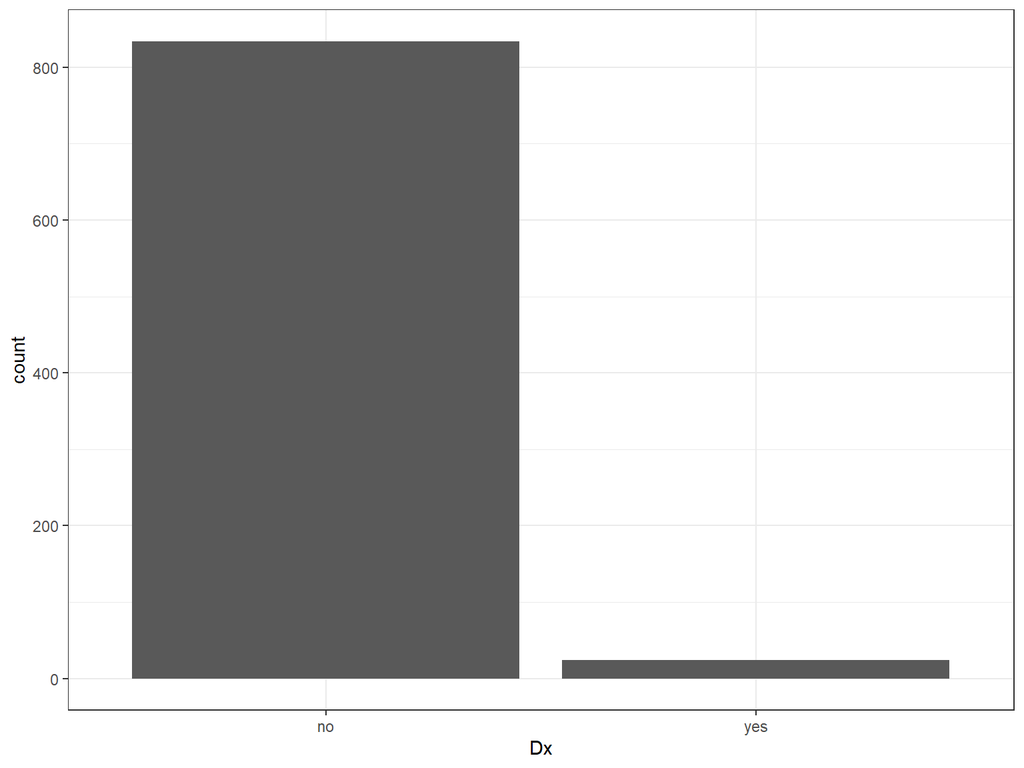

```r
ggplot(dataset, aes(Dx)) + geom_bar() + theme_bw()
```

So, we have 24 positive cases and 834 negative cases for **Dx** (our clasification variable)

# Let’s look at the data

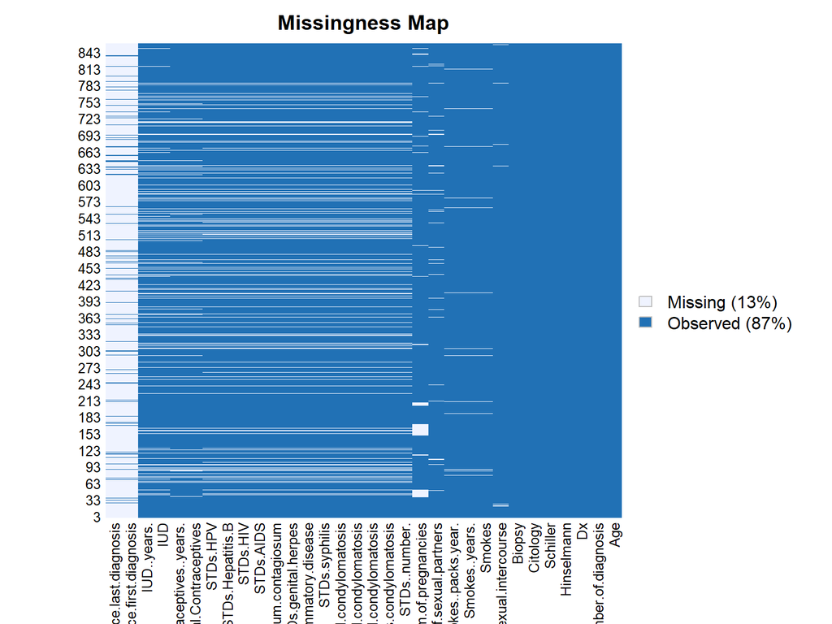

```r
library(Amelia)
# missings on original data
missmap(dataset)
```

With the `amelia` package we can look for missing data

In this case, I will exclude from the analysis variables `STDs..Time.since.first.diagnosis` and `STDs..Time.since.last.diagnosis`

```r
dataset<-dataset %>% select(-STDs..Time.since.first.diagnosis, -STDs..Time.since.last.diagnosis)
```

Although it would be advised to do an imputation of values where we have missing data, I did’nt do it.

# Let’s balance the data

I will use 4 different methods for balance the data and likewise, I will have 4 different datasets to train a regression tree algorithm.

Let’s start with the `caret` package and by downsampling:

```r
library(caret)
set.seed(1)
down_train <- downSample(x = dataset[, !colnames(dataset) %in% "Dx"],
                         y = dataset$Dx)

# we have to remane the Class variable
names(down_train)[30]<-"Dx"

table(down_train$Dx)
```

```
##
##  no yes
##  24  24
```

Now the upsampling:

```r
set.seed(1)
up_train <- upSample(x = dataset[, !colnames(dataset) %in% "Dx"],
                         y = dataset$Dx)

# we have to remane the Class variable
names(up_train)[30]<-"Dx"
table(up_train$Dx)
```

```
##
##  no yes
## 834 834
```

# Let’s balance the data

With the package `DMwR` I will apply the method SMOTE

```r
library(DMwR)
set.seed(1)
smote_train <- SMOTE(Dx ~ ., data  = dataset,
                     perc.over = 400,perc.under=200)
table(smote_train$Dx)
```

```
##
##  no yes
## 192 120
```

and now ROSE (with the package `ROSE`):

```r
library(ROSE)
set.seed(1)
rose_train <- ROSE(Dx ~ ., data  = dataset)$data
table(rose_train$Dx)
```

```
##
##  no yes
## 346 322
```

# Train 4 regression trees algorithms

With the new 4 datasets we can fit the regresssion trees

```r
metric <- "ROC"
control <- trainControl(method = "repeatedcv",
                        number = 10,
                        repeats = 5,
                        summaryFunction=twoClassSummary,
                        classProbs=TRUE,
                        savePredictions = TRUE)

set.seed(2)
fit.rpart.down <- train(Dx ~ ., data=down_train,
                       method="rpart", metric=metric, trControl=control,
                       na.action=na.exclude)

set.seed(2)
fit.rpart.up <- train(Dx ~ ., data=up_train,
                       method="rpart", metric=metric, trControl=control,
                      na.action=na.exclude)

set.seed(2)
fit.rpart.smote <- train(Dx ~ ., data=smote_train,
                       method="rpart", metric=metric, trControl=control,
                      na.action=na.exclude)

set.seed(2)
fit.rpart.rose <- train(Dx ~ ., data=rose_train,
                       method="rpart", metric=metric, trControl=control,
                      na.action=na.exclude)
```

# ROC curves

we can see them in one plot:

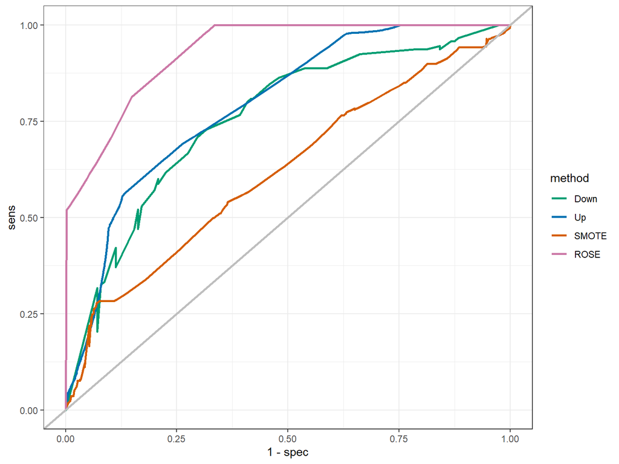

```r
library(pROC)
# combine the results
ggroc<-rbind(data.frame(method = "Down",
                       sens=roc(fit.rpart.down$pred$obs,fit.rpart.down$pred$yes)$sensitivities,
                       spec=roc(fit.rpart.down$pred$obs,fit.rpart.down$pred$yes)$specificities),
             data.frame(method = "Up",
                       sens=roc(fit.rpart.up$pred$obs,fit.rpart.up$pred$yes)$sensitivities,
                       spec=roc(fit.rpart.up$pred$obs,fit.rpart.up$pred$yes)$specificities),
             data.frame(method = "SMOTE",
                       sens=roc(fit.rpart.smote$pred$obs,fit.rpart.smote$pred$yes)$sensitivities,
                       spec=roc(fit.rpart.smote$pred$obs,fit.rpart.smote$pred$yes)$specificities),
             data.frame(method = "ROSE",
                       sens=roc(fit.rpart.rose$pred$obs,fit.rpart.rose$pred$yes)$sensitivities,
                       spec=roc(fit.rpart.rose$pred$obs,fit.rpart.rose$pred$yes)$specificities)
)

custom_col <- c("#009E73", "#0072B2", "#D55E00", "#CC79A7")

ggplot(ggroc, aes(x= 1-spec, y= sens, group = method)) +
  geom_line(aes(color = method), size = 1) +
  scale_color_manual(values = custom_col) +
  geom_abline(intercept = 0, slope = 1, color = "gray", size = 1) +
    theme_bw()
```

# And compare accuracies

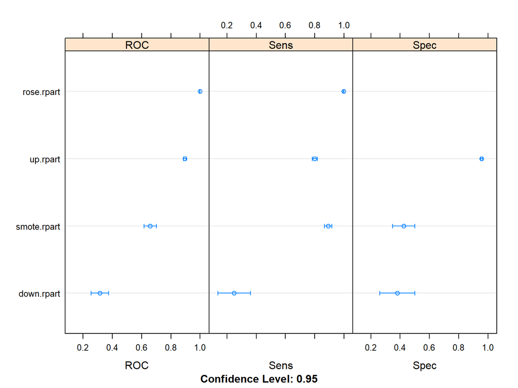

```r
fit.models <- list(down.rpart=fit.rpart.down,
                   up.rpart=fit.rpart.up,
                   smote.rpart= fit.rpart.smote,
                   rose.rpart= fit.rpart.rose)


results <- resamples(fit.models)

dotplot(results)
```

In this exercise we obtained the best results with ROSE dataset. Although we can have a problem of overfitting.

# Real world framework

- do exploratory data analysis
- look for missing data
- exclude variables with more than 80% missings
- try to input data to other remaining missings
- do data partition between training data set and testing data set
- balance your training dataset
- train your algorithms with the training dataset
- test them in your testing dataset
- **DO NOT** balance your testing dataset

# References